# Optimal Portfolios: Mean-Variance, CAPM and Shrinkage

Maastricht University, eLab Business Case

Francisca Freixo

# 2. Assignment

# 2.1 - Data

## Question 9

To ensure consistency with the stock return data, the annualized percentage risk-free rate must be transformed into a daily or monthly decimal rate by dividing it by 100 and then dividing by 252 for daily returns. This transformation aligns the units of the risk-free rate with those of the stock returns, enabling accurate calculation of excess returns and portfolio optimization. Right now, my stock returns are in daily returns, while the risk-free rate is an annualized percentage, so I will convert the risk-free rate to daily returns.

```r
tickers <- read.csv("data/teamticker.csv", header = TRUE)
symbols <- na.omit(as.character(tickers$D))  # Team D

getSymbols(symbols, from = "2003-12-31")
```

```
##  [1] "SPY"  "DVN"  "EPP"  "LEN"  "ALB"  "UFI"  "SGRP" "HIO"  "CHD"  "B"
## [11] "XLE"  "TGI"  "TKC"  "CSGP" "AAPL" "IJT"  "IRIX" "CVR"  "NNBR" "CIA"
```

```r
prices    <- do.call(merge, lapply(symbols, function(sym) Ad(get(sym))))

returns   <- ROC(prices, type = "discrete")

getSymbols("DTB3", src = "FRED", from = "2003-12-31")
```

```
## [1] "DTB3"
```

```r
rf_daily  <- DTB3 / 100 / 252    # percent → decimal, annual → daily
colnames(rf_daily) <- "rf"

rf_filled <- na.locf(rf_daily)
rf_lagged <- xts::lag.xts(rf_filled, k = 1)

rf_aligned  <- rf_lagged[index(returns)]
data_merged <- na.omit(merge(returns, rf_aligned))

head(data_merged)
```

```
##             SPY.Adjusted  DVN.Adjusted  EPP.Adjusted LEN.Adjusted  ALB.Adjusted
## 2004-01-02 -0.0004492032  0.0003491995  0.0194533900  -0.02302091  0.0093429638
## 2004-01-05  0.0108781767  0.0195528285  0.0110977297  -0.01343408  0.0066117598
## 2004-01-06  0.0009784762 -0.0035953884  0.0104403476   0.02096630 -0.0003286427
## 2004-01-07  0.0033759867  0.0010305403 -0.0017221079  -0.01270262  0.0016426441
## 2004-01-08  0.0039849677  0.0018885333  0.0009289087  -0.04084924 -0.0006559971
## 2004-01-09 -0.0087318712  0.0161068029 -0.0034470429   0.03051646 -0.0219890928
##            UFI.Adjusted SGRP.Adjusted HIO.Adjusted  CHD.Adjusted    B.Adjusted
## 2004-01-02 -0.001550423  -0.003124997  0.001394438 -0.0025255537  0.0118882891
## 2004-01-05  0.001552831   0.018808759  0.004178027  0.0116451516  0.0182769632
## 2004-01-06  0.009302341   0.006153840  0.006935551 -0.0045041501 -0.0192301339
## 2004-01-07 -0.009216605   0.000000000  0.017906588  0.0025142204 -0.0100225565
## 2004-01-08 -0.013953512  -0.003058101 -0.004060869  0.0007519168 -0.0044009550
## 2004-01-09  0.006289352   0.000000000  0.005436078 -0.0107742611  0.0008837563
##             XLE.Adjusted TGI.Adjusted  TKC.Adjusted CSGP.Adjusted AAPL.Adjusted
## 2004-01-02 -0.0003628583  0.018955611 -0.0143126326   0.010791385  -0.004211020
## 2004-01-05  0.0192446346  0.019682179  0.1329768617   0.001660728   0.041823506
## 2004-01-06 -0.0010684699 -0.021682028 -0.0792579248  -0.009711011  -0.003609816
## 2004-01-07 -0.0103426076  0.008108083 -0.0054945276  -0.007892960   0.022636152
## 2004-01-08  0.0028828097  0.020107446  0.0007363593   0.010125433   0.034085711
## 2004-01-09  0.0050302612 -0.017082923  0.0581525809  -0.020763697  -0.015412294
##            IJT.Adjusted IRIX.Adjusted CVR.Adjusted NNBR.Adjusted CIA.Adjusted
## 2004-01-02  0.000563079  -0.009174260  0.003332246   0.034235627   0.01908801
## 2004-01-05  0.010251098  -0.057407396  0.009225444  -0.022325087   0.04058272
## 2004-01-06  0.005687227   0.021610934  0.000000000  -0.007086472  -0.02699999
## 2004-01-07  0.005876606   0.036538474  0.000000000   0.000000000   0.01233288
## 2004-01-08  0.003306992  -0.018552858  0.000000000   0.005551209   0.01319812
## 2004-01-09 -0.011206993  -0.001890312 -0.003657008  -0.026813889  -0.04609221
##                      rf
## 2004-01-02 3.690476e-05
## 2004-01-05 3.611111e-05
## 2004-01-06 3.571429e-05
## 2004-01-07 3.571429e-05
## 2004-01-08 3.531746e-05
## 2004-01-09 3.412698e-05
```

```r
returns <- returns[index(rf_aligned)]  # Trim returns to match rf

rf_matrix <- matrix(rep(coredata(rf_aligned), ncol(returns)),
                    nrow = nrow(returns), ncol = ncol(returns))

excess_returns <- returns - rf_matrix
colnames(excess_returns) <- colnames(returns)
```

# 2.2 + 2.3 - Mean Variance Problem + Cross Validation

## Question 10

To begin Question 10, I split the dataset into two subsets: observations from odd days and the other from even days. This creates two independent samples that can be used for cross-validation.

Next, I calculated the average excess returns and standard deviations for each stock separately within the odd and even subsamples. This provides two sets of statistics, one per subsample, to compare the consistency of the return distribution over time.

To see how similar the estimates are between the two folds, I plot the mean returns of the odd subsample on the x-axis and the even subsample on the y-axis. I repeat this procedure for the standard deviations. If the points lie close to the 45-degree line, it shows consistency between the subsamples.

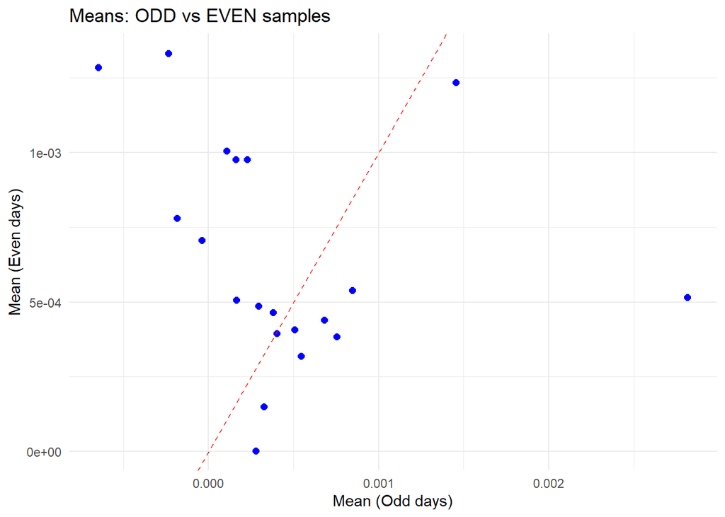

```r
# Step 1: Create ODD and EVEN subsets (row-wise)
odd_index <- seq(1, nrow(excess_returns), by = 2)
even_index <- seq(2, nrow(excess_returns), by = 2)

excess_odd <- excess_returns[odd_index, ]
excess_even <- excess_returns[even_index, ]

# Step 2: Compute column-wise means and standard deviations
mean_odd <- colMeans(excess_odd, na.rm = TRUE)
mean_even <- colMeans(excess_even, na.rm = TRUE)

sd_odd <- apply(excess_odd, 2, sd, na.rm = TRUE)
sd_even <- apply(excess_even, 2, sd, na.rm = TRUE)

# Step 3: Combine means and SDs into data frames for plotting
df_mean <- data.frame(Mean_Odd = mean_odd, Mean_Even = mean_even)
df_sd   <- data.frame(SD_Odd = sd_odd, SD_Even = sd_even)


ggplot(df_mean, aes(x = Mean_Odd, y = Mean_Even)) +
  geom_point(color = "blue", size = 2) +
  geom_abline(intercept = 0, slope = 1, color = "red", linetype = "dashed") +
  labs(title = "Means: ODD vs EVEN samples",
       x = "Mean (Odd days)",
       y = "Mean (Even days)") +
  theme_minimal()
```

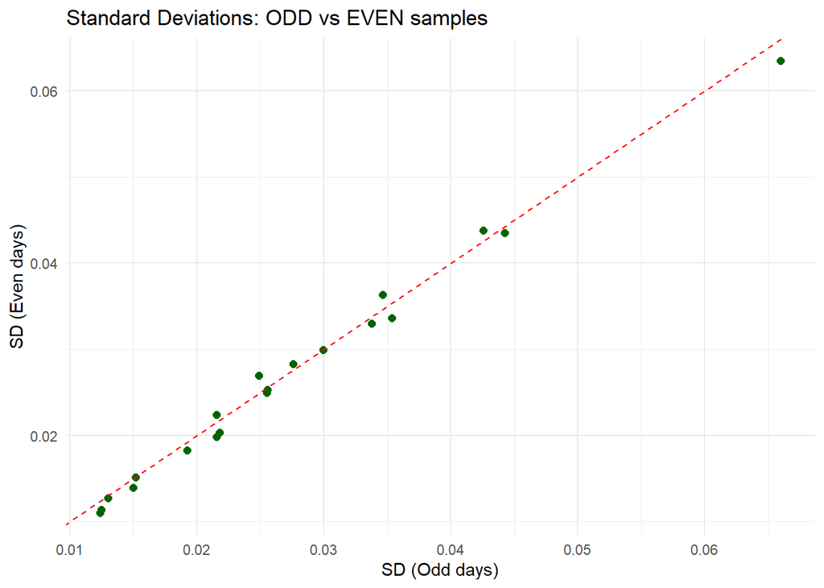

```r
# Step 5: Plot standard deviations
ggplot(df_sd, aes(x = SD_Odd, y = SD_Even)) +
  geom_point(color = "darkgreen", size = 2) +
  geom_abline(intercept = 0, slope = 1, color = "red", linetype = "dashed") +
  labs(title = "Standard Deviations: ODD vs EVEN samples",
       x = "SD (Odd days)",
       y = "SD (Even days)") +
  theme_minimal()
```

The means differ between odd and even samples, as seen by the scatter around the 45-degree line. This suggests that average excess returns change a lot across subsamples, indicating noise in the data and potential overfitting risk when using raw means.

Standard deviations are much more consistent across samples, the points are closely aligned to the 45-degree line. This indicates that volatility is stable and more reliable than mean returns for portfolio input.

### Would you expect significant differences?

To test whether the average excess returns differ significantly between odd and even days, I computed the difference in means for each stock and ran a paired t-test. This test assesses whether the mean of the differences is statistically different from zero. I also visualized the distribution of these differences using a histogram.

```r
#checking for significance in means
mean_diff <- mean_odd - mean_even

t_result <- t.test(mean_odd, mean_even, paired = TRUE)

print(t_result)
```

```
##
##  Paired t-test
##
## data:  mean_odd and mean_even
## t = -1.0344, df = 19, p-value = 0.3139
## alternative hypothesis: true mean difference is not equal to 0
## 95 percent confidence interval:
##  -0.0006178230  0.0002091206
## sample estimates:
## mean difference
##   -0.0002043512
```

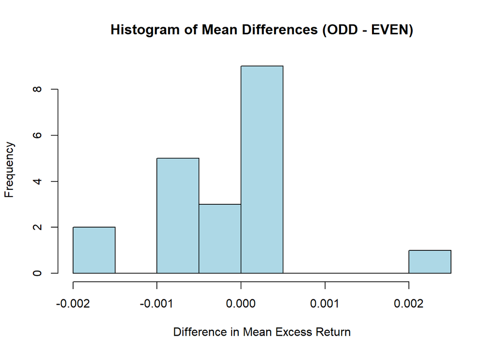

```r
hist(mean_diff, breaks = 10, main = "Histogram of Mean Differences (ODD - EVEN)",
     xlab = "Difference in Mean Excess Return", col = "lightblue")
```

## Question 11

In Question 11, I constructed four optimized portfolios using mean-variance analysis. First, I built two portfolios using the odd and even subsamples separately, allowing short-selling (so weights could be negative). Then, I repeated the same process but with short-selling not allowed, meaning all portfolio weights had to be zero or positive. In all portfolios, I included the risk-free asset by optimizing based on excess returns. This allowed me to compare how the portfolios differ depending on the data sample and whether or not short-selling is permitted. This resulted in four distinct portfolios with four differnt weights.

```r
gamma <- 3

optimize_portfolio <- function(R, short_selling = TRUE) {
  R <- R[complete.cases(R), ]

  mu <- colMeans(R)
  S <- cov(R, use = "pairwise.complete.obs")
  S <- S + diag(1e-6, ncol(S))

  N <- ncol(S)
  Dmat <- 2 * gamma * S
  dvec <- mu

  if (short_selling) {
    Amat <- diag(N)
    bvec <- rep(-1e10, N)
    meq <- 0
  } else {
    Amat <- diag(N)
    bvec <- rep(0, N)
    meq <- 0
  }

  result <- solve.QP(Dmat, dvec, Amat, bvec, meq)
  weights <- result$solution
  names(weights) <- colnames(R)
  return(weights)
}
```

Lastly, I printed out the weights for each portfolio and calculated the weight allocated to the risk-free asset, using the fact that the remaining weight not invested in risky assets is automatically allocated there.

```r
odd_index <- seq(1, nrow(excess_returns), by = 2)
even_index <- seq(2, nrow(excess_returns), by = 2)

excess_odd <- excess_returns[odd_index, ]
excess_even <- excess_returns[even_index, ]

excess_odd <- excess_odd[complete.cases(excess_odd), ]
excess_even <- excess_even[complete.cases(excess_even), ]

w_odd_free     <- optimize_portfolio(excess_odd,  short_selling = TRUE)
w_odd_noshort  <- optimize_portfolio(excess_odd,  short_selling = FALSE)

w_even_free    <- optimize_portfolio(excess_even, short_selling = TRUE)
w_even_noshort <- optimize_portfolio(excess_even, short_selling = FALSE)


print_weights <- function(w, title = "Portfolio Weights") {
  df <- tibble(
    Asset = names(w),
    Weight = round(w, 3)
  ) %>%
    filter(Weight != 0) %>%
    arrange(desc(abs(Weight)))
  kable(df, format = "html", caption = title) %>%
    kable_styling(bootstrap_options = c("striped", "hover", "condensed", "responsive"), full_width = F)
}

print_weights(w_odd_free, "ODD Sample - Short-Selling Allowed")
```

ODD Sample - Short-Selling Allowed

| Asset | Weight |
| --- | --- |
| SPY.Adjusted | -0.920 |
| EPP.Adjusted | -0.890 |
| CHD.Adjusted | 0.740 |
| AAPL.Adjusted | 0.704 |
| IJT.Adjusted | 0.700 |
| HIO.Adjusted | 0.381 |
| CSGP.Adjusted | 0.290 |
| XLE.Adjusted | 0.265 |
| UFI.Adjusted | -0.158 |
| TKC.Adjusted | 0.152 |
| LEN.Adjusted | -0.143 |
| SGRP.Adjusted | 0.108 |
| CVR.Adjusted | 0.102 |
| NNBR.Adjusted | -0.094 |
| ALB.Adjusted | -0.093 |
| B.Adjusted | -0.079 |
| DVN.Adjusted | 0.070 |
| IRIX.Adjusted | 0.051 |
| TGI.Adjusted | -0.050 |
| CIA.Adjusted | -0.044 |

```r
print_weights(w_odd_noshort, "ODD Sample - No Short-Selling")
```

ODD Sample - No Short-Selling

| Asset | Weight |
| --- | --- |
| CHD.Adjusted | 0.525 |
| AAPL.Adjusted | 0.408 |
| SGRP.Adjusted | 0.110 |
| CVR.Adjusted | 0.055 |
| CSGP.Adjusted | 0.052 |
| IRIX.Adjusted | 0.015 |

```r
print_weights(w_even_free, "EVEN Sample - Short-Selling Allowed")
```

EVEN Sample - Short-Selling Allowed

| Asset | Weight |
| --- | --- |
| IJT.Adjusted | -1.065 |
| AAPL.Adjusted | 0.498 |
| EPP.Adjusted | 0.392 |
| CHD.Adjusted | 0.246 |
| ALB.Adjusted | 0.144 |
| UFI.Adjusted | 0.136 |
| LEN.Adjusted | 0.130 |
| B.Adjusted | 0.123 |
| DVN.Adjusted | -0.119 |
| TGI.Adjusted | 0.111 |
| HIO.Adjusted | -0.107 |
| NNBR.Adjusted | 0.082 |
| CSGP.Adjusted | 0.078 |
| TKC.Adjusted | -0.048 |
| XLE.Adjusted | 0.047 |
| CVR.Adjusted | -0.028 |
| IRIX.Adjusted | 0.018 |
| SGRP.Adjusted | 0.015 |
| SPY.Adjusted | 0.010 |
| CIA.Adjusted | -0.009 |

```r
print_weights(w_even_noshort, "EVEN Sample - No Short-Selling")
```

EVEN Sample - No Short-Selling

| Asset | Weight |
| --- | --- |
| AAPL.Adjusted | 0.407 |
| CHD.Adjusted | 0.167 |
| B.Adjusted | 0.124 |
| UFI.Adjusted | 0.090 |
| NNBR.Adjusted | 0.044 |
| LEN.Adjusted | 0.028 |
| ALB.Adjusted | 0.025 |
| SGRP.Adjusted | 0.014 |
| TGI.Adjusted | 0.013 |
| IRIX.Adjusted | 0.006 |

```r
weight_riskfree_odd_free     <- 1 - sum(w_odd_free)
weight_riskfree_odd_noshort  <- 1 - sum(w_odd_noshort)
weight_riskfree_even_free    <- 1 - sum(w_even_free)
weight_riskfree_even_noshort <- 1 - sum(w_even_noshort)


cat("Weight in risk-free asset (ODD, short):", round(weight_riskfree_odd_free, 3), "\n")
```

```
## Weight in risk-free asset (ODD, short): -0.092
```

```r
cat("Weight in risk-free asset (ODD, no short):", round(weight_riskfree_odd_noshort, 3), "\n")
```

```
## Weight in risk-free asset (ODD, no short): -0.164
```

```r
cat("Weight in risk-free asset (EVEN, short):", round(weight_riskfree_even_free, 3), "\n")
```

```
## Weight in risk-free asset (EVEN, short): 0.345
```

```r
cat("Weight in risk-free asset (EVEN, no short):", round(weight_riskfree_even_noshort, 3), "\n")
```

```
## Weight in risk-free asset (EVEN, no short): 0.08
```

```r
#cat("**Weight in risk-free asset:**", round(weight_riskfree, 3), "\n")
```

### Bar Plots

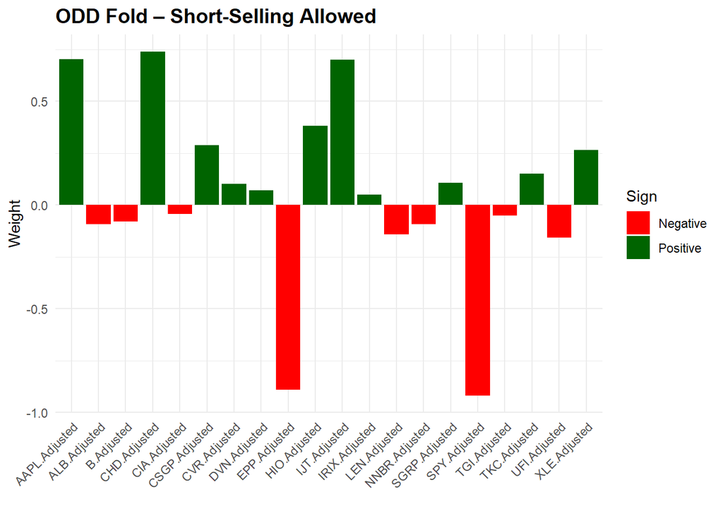

```r
weights_df <- data.frame(
  Ticker = names(w_odd_free),
  Odd_Short        = w_odd_free,
  Odd_NoShort      = w_odd_noshort,
  Even_Short       = w_even_free,
  Even_NoShort     = w_even_noshort
)

weights_long <- weights_df %>%
  pivot_longer(cols = -Ticker, names_to = "Portfolio", values_to = "Weight") %>%
  mutate(Sign = ifelse(Weight >= 0, "Positive", "Negative"))

plot_portfolio_weights <- function(data, title) {
  ggplot(data, aes(x = Ticker, y = Weight, fill = Sign)) +
    geom_bar(stat = "identity") +
    scale_fill_manual(values = c("Positive" = "darkgreen", "Negative" = "red")) +
    theme_minimal() +
    labs(title = title, x = "", y = "Weight") +
    theme(axis.text.x = element_text(angle = 45, hjust = 1),
          plot.title = element_text(size = 14, face = "bold"))
}

plot_odd_short      <- plot_portfolio_weights(filter(weights_long, Portfolio == "Odd_Short"),     "ODD Fold – Short-Selling Allowed")
plot_odd_noshort    <- plot_portfolio_weights(filter(weights_long, Portfolio == "Odd_NoShort"),   "ODD Fold – No Short-Selling")
plot_even_short     <- plot_portfolio_weights(filter(weights_long, Portfolio == "Even_Short"),    "EVEN Fold – Short-Selling Allowed")
plot_even_noshort   <- plot_portfolio_weights(filter(weights_long, Portfolio == "Even_NoShort"),  "EVEN Fold – No Short-Selling")

print(plot_odd_short)
```

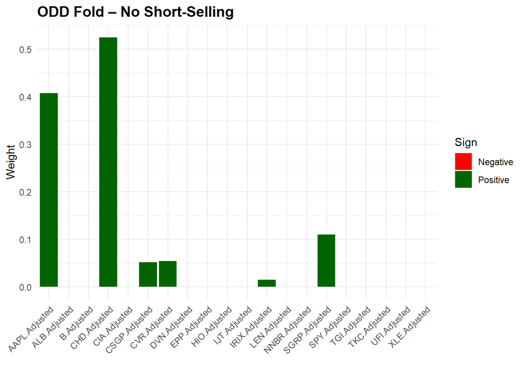

```r
print(plot_odd_noshort)
```

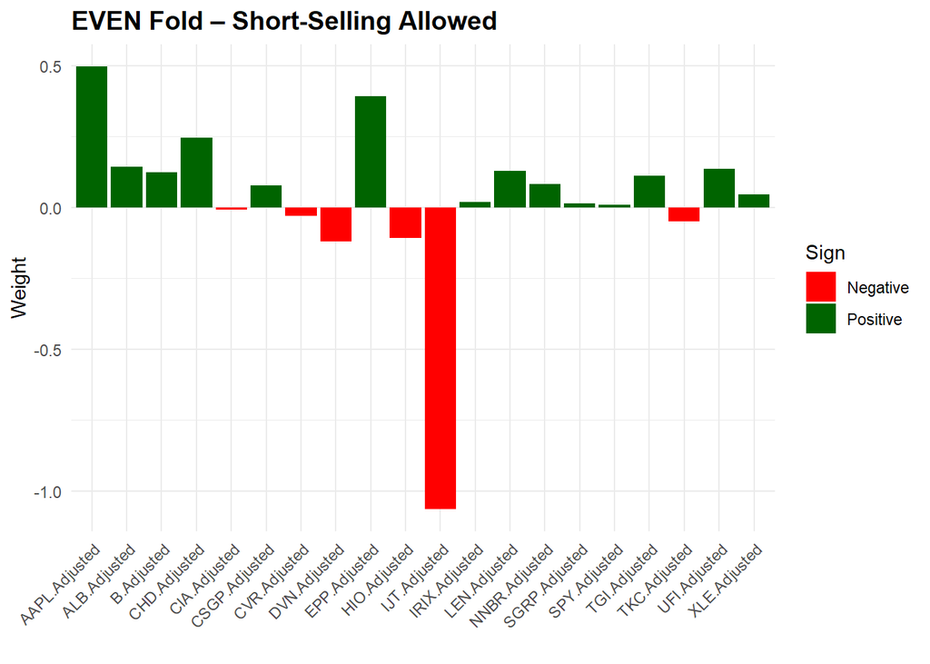

```r
print(plot_even_short)
```

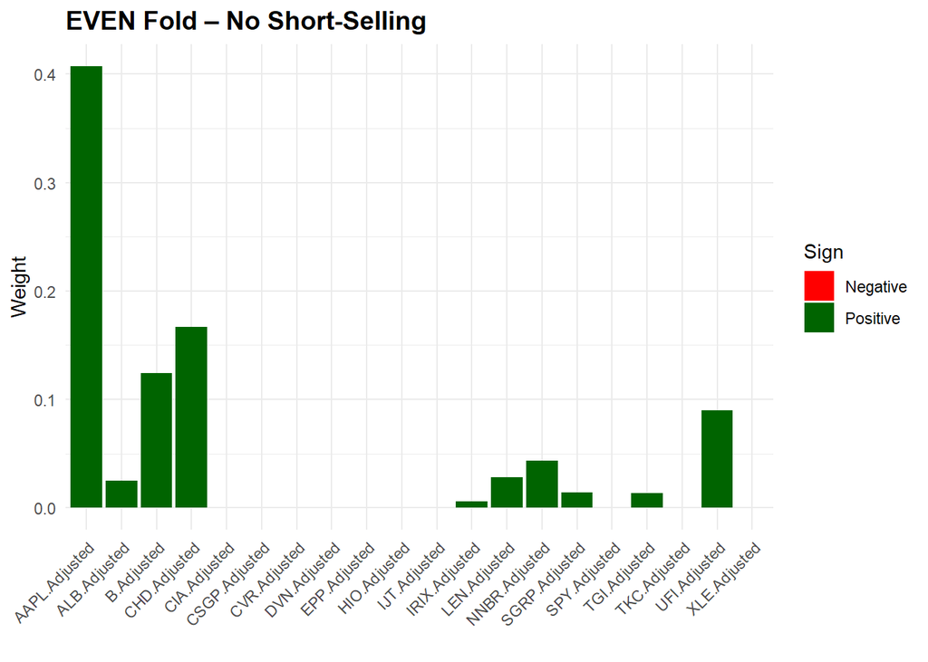

```r
print(plot_even_noshort)
```

## Question 12

In Question 12, I evaluated the performance of the optimized portfolios from Question 11. For each portfolio, I calculated the expected excess return and standard deviation in the training sample (where it was optimized). Then, I tested each portfolio’s performance in the validation sample, by applying the weights obtained from one fold to the returns of the other fold. This gave me a view of how well the optimized portfolio generalized to new data.

```r
evaluate_portfolio <- function(w, returns) {
  port_returns <- returns %*% w
  mean <- mean(port_returns)
  sd <- sd(port_returns)
  sharpe <- mean / sd
  return(list(mean = mean, sd = sd, sharpe = sharpe))
}
```

```r
# in-sample
perf_odd_free     <- evaluate_portfolio(w_odd_free, excess_odd)
perf_odd_noshort  <- evaluate_portfolio(w_odd_noshort, excess_odd)
perf_even_free    <- evaluate_portfolio(w_even_free, excess_even)
perf_even_noshort <- evaluate_portfolio(w_even_noshort, excess_even)

# out-of-sample
val_odd_free     <- evaluate_portfolio(w_odd_free, excess_even)
val_odd_noshort  <- evaluate_portfolio(w_odd_noshort, excess_even)
val_even_free    <- evaluate_portfolio(w_even_free, excess_odd)
val_even_noshort <- evaluate_portfolio(w_even_noshort, excess_odd)
```

After calculating the portfolio’s excess return and standard deviation for both the training and validation samples, I annualized the results. To do this, I multiplied the average daily return by 252 (the approximate number of trading days in a year), and multiplied the daily standard deviation by √252. This ensures the performance metrics are on a comparable annual scale. To summarize the results, I created tables showing the average excess return, standard deviation, and Sharpe ratio for all four portfolios, both in-sample and out-of-sample.

```r
annualize <- function(perf) {
  list(
    mean   = perf$mean * 252,
    sd     = perf$sd * sqrt(252),
    sharpe = perf$sharpe
  )
}

perf_odd_free_annual     <- annualize(perf_odd_free)
perf_odd_noshort_annual  <- annualize(perf_odd_noshort)
perf_even_free_annual    <- annualize(perf_even_free)
perf_even_noshort_annual <- annualize(perf_even_noshort)

val_odd_free_annual     <- annualize(val_odd_free)
val_odd_noshort_annual  <- annualize(val_odd_noshort)
val_even_free_annual    <- annualize(val_even_free)
val_even_noshort_annual <- annualize(val_even_noshort)

results_annual <- data.frame(
  Portfolio = rep(c("ODD - short", "ODD - no short", "EVEN - short", "EVEN - no short"), each = 2),
  Evaluation = rep(c("In-sample", "Out-of-sample"), times = 4),
  AnnualReturn = c(
    perf_odd_free_annual$mean, val_odd_free_annual$mean,
    perf_odd_noshort_annual$mean, val_odd_noshort_annual$mean,
    perf_even_free_annual$mean, val_even_free_annual$mean,
    perf_even_noshort_annual$mean, val_even_noshort_annual$mean
  ),
  AnnualSD = c(
    perf_odd_free_annual$sd, val_odd_free_annual$sd,
    perf_odd_noshort_annual$sd, val_odd_noshort_annual$sd,
    perf_even_free_annual$sd, val_even_free_annual$sd,
    perf_even_noshort_annual$sd, val_even_noshort_annual$sd
  ),
  SharpeRatio = c(
    perf_odd_free_annual$sharpe, val_odd_free_annual$sharpe,
    perf_odd_noshort_annual$sharpe, val_odd_noshort_annual$sharpe,
    perf_even_free_annual$sharpe, val_even_free_annual$sharpe,
    perf_even_noshort_annual$sharpe, val_even_noshort_annual$sharpe
  )
)

results_annual_rounded <- results_annual
results_annual_rounded[, c("AnnualReturn", "AnnualSD", "SharpeRatio")] <-
  round(results_annual_rounded[, c("AnnualReturn", "AnnualSD", "SharpeRatio")], 3)

extract_metric_table <- function(df, portfolio_type, metric_col) {
  matrix(c(
    df[df$Portfolio == paste0("ODD - ", portfolio_type) & df$Evaluation == "In-sample", metric_col],
    df[df$Portfolio == paste0("ODD - ", portfolio_type) & df$Evaluation == "Out-of-sample", metric_col],
    df[df$Portfolio == paste0("EVEN - ", portfolio_type) & df$Evaluation == "In-sample", metric_col],
    df[df$Portfolio == paste0("EVEN - ", portfolio_type) & df$Evaluation == "Out-of-sample", metric_col]
  ), nrow = 2, byrow = TRUE,
  dimnames = list(c("ODD", "EVEN"), c("ODD Eval", "EVEN Eval")))
}

sharpe_unconstr <- extract_metric_table(results_annual_rounded, "short", "SharpeRatio")
return_unconstr <- extract_metric_table(results_annual_rounded, "short", "AnnualReturn")
sd_unconstr     <- extract_metric_table(results_annual_rounded, "short", "AnnualSD")

cat("### Unconstrained Portfolios (Short-Selling Allowed)\n\n")
```

```
## ### Unconstrained Portfolios (Short-Selling Allowed)
```

```r
kable(sharpe_unconstr, caption = "Sharpe Ratios (Unconstrained)") %>% kable_styling()
```

Sharpe Ratios (Unconstrained)

|  | ODD Eval | EVEN Eval |
| --- | --- | --- |
| ODD | 0.127 | 0.008 |
| EVEN | 0.090 | 0.027 |

```r
kable(return_unconstr, caption = "Annual Returns (Unconstrained)") %>% kable_styling()
```

Annual Returns (Unconstrained)

|  | ODD Eval | EVEN Eval |
| --- | --- | --- |
| ODD | 0.673 | 0.040 |
| EVEN | 0.336 | 0.102 |

```r
kable(sd_unconstr, caption = "Annual Std Dev (Unconstrained)") %>% kable_styling()
```

Annual Std Dev (Unconstrained)

|  | ODD Eval | EVEN Eval |
| --- | --- | --- |
| ODD | 0.334 | 0.332 |
| EVEN | 0.236 | 0.242 |

```r
sharpe_constr <- extract_metric_table(results_annual_rounded, "no short", "SharpeRatio")
return_constr <- extract_metric_table(results_annual_rounded, "no short", "AnnualReturn")
sd_constr     <- extract_metric_table(results_annual_rounded, "no short", "AnnualSD")

cat("\n\n### Constrained Portfolios (No Short-Selling)\n\n")
```

```
##
##
## ### Constrained Portfolios (No Short-Selling)
```

```r
kable(sharpe_constr, caption = "Sharpe Ratios (Constrained)") %>% kable_styling()
```

Sharpe Ratios (Constrained)

|  | ODD Eval | EVEN Eval |
| --- | --- | --- |
| ODD | 0.091 | 0.056 |
| EVEN | 0.074 | 0.050 |

```r
kable(return_constr, caption = "Annual Returns (Constrained)") %>% kable_styling()
```

Annual Returns (Constrained)

|  | ODD Eval | EVEN Eval |
| --- | --- | --- |
| ODD | 0.344 | 0.201 |
| EVEN | 0.230 | 0.172 |

```r
kable(sd_constr, caption = "Annual Std Dev (Constrained)") %>% kable_styling()
```

Annual Std Dev (Constrained)

|  | ODD Eval | EVEN Eval |
| --- | --- | --- |
| ODD | 0.239 | 0.225 |
| EVEN | 0.196 | 0.214 |

**Conclusions** **Unconstrained portfolios** The Sharpe ratios for unconstrained portfolios show a worse performance from the in-sample result to the out-of-sample performance. For example, the ODD fold drops from 0.127 to 0.008, and the EVEN fold drops from 0.090 to 0.027. This is a very significant decline, and it suggests that the portfolios are overfitted to their training data and therefore fail to maintain their performance when evaluated on new data.

Despite the large differences in return and Sharpe ratio, the standard deviations for unconstrained portfolios remain quite stable. For ODD, the standard deviation is 33.3% in-sample and 33.2% out-of-sample, whilst for EVEN, it goes from 23.6% to 24.3%. This indicates that the level of risk remains the same, but the rewards do not, this makes the reliability of these portfolios worse.

### Bar Plots

We also thought that turning these numbers into visualizations would greatly improve and ease the understanding of them, so below you can see these same numbers and conclusions but in a visual way.

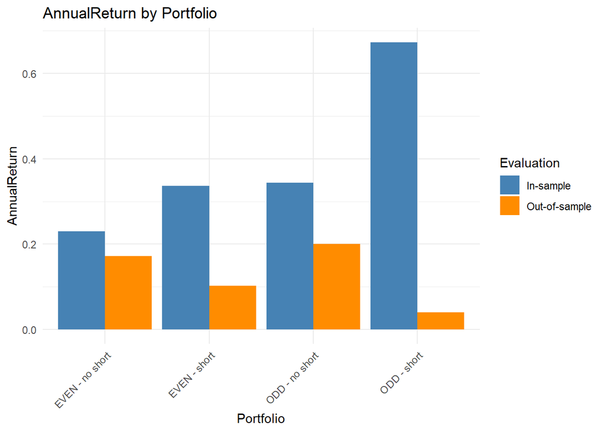

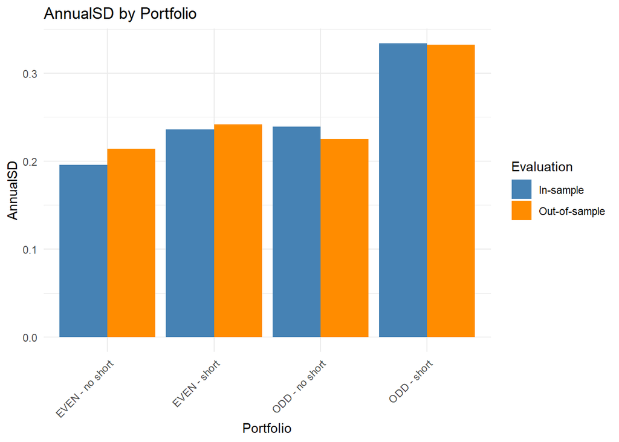

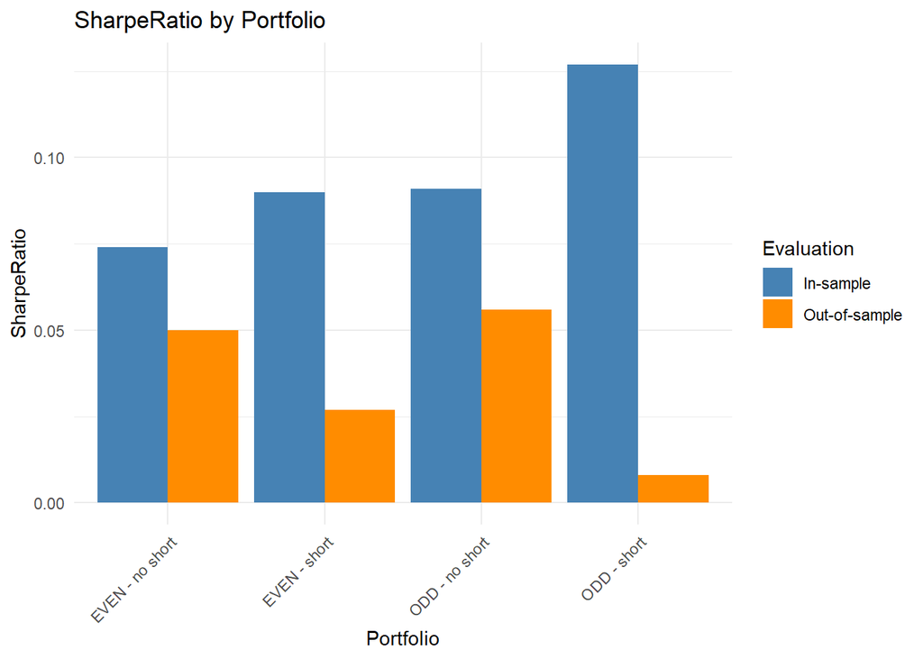

```r
metrics <- c("AnnualReturn", "AnnualSD", "SharpeRatio")

for (metric in metrics) {
  p <- ggplot(results_annual_rounded, aes_string(x = "Portfolio", y = metric, fill = "Evaluation")) +
    geom_bar(stat = "identity", position = "dodge") +
    labs(title = paste(metric, "by Portfolio"),
         y = metric, x = "Portfolio") +
    theme_minimal() +
    scale_fill_manual(values = c("In-sample" = "steelblue", "Out-of-sample" = "darkorange")) +
    theme(axis.text.x = element_text(angle = 45, hjust = 1))

  print(p)
}
```

## Question 13

Based on theory, asset weights are given to maximize the portfolio’s expected return for a given level of risks. SPY, like all other asset in the portfolio, is evaluated purely on its statistical contribution to risk and return. Therefore, unless SPY demonstrates a very high return or offers strong diversification relative to the other assets, its optimal weight is expected to be low. If short-selling is allowed and SPY is not favorable in terms of its return-to-risk profile, the optimizer may even assign it a negative weight. This approach differs with CAPM-based models, where SPY would receive more weight due to its role as the market proxy.

```r
spy_name <- "SPY.Adjusted"

cat("SPY weight in w_odd_free:    ", round(w_odd_free[spy_name], 4), "\n")
```

```
## SPY weight in w_odd_free:     -0.9204
```

```r
cat("SPY weight in w_odd_noshort: ", round(w_odd_noshort[spy_name], 4), "\n")
```

```
## SPY weight in w_odd_noshort:  0
```

```r
cat("SPY weight in w_even_free:   ", round(w_even_free[spy_name], 4), "\n")
```

```
## SPY weight in w_even_free:    0.0101
```

```r
cat("SPY weight in w_even_noshort:", round(w_even_noshort[spy_name], 4), "\n")
```

```
## SPY weight in w_even_noshort: 0
```

In our results, SPY received a small or negative weight in some portfolios, which aligns with theory. This means that SPY did not stand out in terms of return or diversification, so the optimizer allocated less weight to it.

# 2.4 - CAPM BETA’s

## Question 14

In Question 14, I computed the CAPM beta for each stock in my dataset. To do this, I used a regression, where I regressed the excess return of each stock on the excess return of the market - using SPY as a market proxy. The slope of this regression is the coefficient on the market return and represents the stock’s beta. I performed this regression separately for the odd and even subsamples. After calculating the betas, I created a scatterplot comparing the beta values from the odd sample (x-axis) and the even sample (y-axis). This helped me visually assess how consistent the beta estimates are across the two samples.

```r
# Estimate betas q11
estimate_betas <- function(returns_xts, market_name = "SPY.Adjusted") {
  market <- returns_xts[, market_name]
  betas <- sapply(returns_xts, function(asset) {
    cov(asset, market, use = "complete.obs") / var(market, na.rm = TRUE)
  })
  return(betas)
}

betas <- estimate_betas(excess_returns)

# Estimate expected SPY
mean_market_excess_return <- mean(excess_returns[, "SPY.Adjusted"], na.rm = TRUE)

# CAPM expected returns
mu_capm <- betas * mean_market_excess_return

# Optimizer using CAPM
optimize_portfolio_capm <- function(R, mu_override, short_selling = TRUE) {
  R <- R[complete.cases(R), ]
  S <- cov(R, use = "pairwise.complete.obs")
  S <- S + diag(1e-6, ncol(S))

  N <- ncol(R)
  Dmat <- 2 * gamma * S
  dvec <- mu_override[colnames(R)]

  if (short_selling) {
    Amat <- diag(N)
    bvec <- rep(-1e10, N)
  } else {
    Amat <- diag(N)
    bvec <- rep(0, N)
  }

  result <- solve.QP(Dmat, dvec, Amat, bvec, meq = 0)
  weights <- result$solution
  names(weights) <- colnames(R)
  return(weights)
}

w_odd_free_capm     <- optimize_portfolio_capm(excess_odd, mu_capm, TRUE)
w_odd_noshort_capm  <- optimize_portfolio_capm(excess_odd, mu_capm, FALSE)
w_even_free_capm    <- optimize_portfolio_capm(excess_even, mu_capm, TRUE)
w_even_noshort_capm <- optimize_portfolio_capm(excess_even, mu_capm, FALSE)

# Weights
## CAPM Weights
weights_capm_df <- data.frame(
  Ticker = names(w_odd_free_capm),
  CAPM_Odd_Short     = round(w_odd_free_capm, 5),
  CAPM_Odd_NoShort   = round(w_odd_noshort_capm, 5),
  CAPM_Even_Short    = round(w_even_free_capm, 5),
  CAPM_Even_NoShort  = round(w_even_noshort_capm, 5)
)

## Weights from Q11
weights_q11_df <- data.frame(
  Ticker = names(w_odd_free),
  Empirical_Odd_Short     = round(w_odd_free, 5),
  Empirical_Odd_NoShort   = round(w_odd_noshort, 5),
  Empirical_Even_Short    = round(w_even_free, 5),
  Empirical_Even_NoShort  = round(w_even_noshort, 5)
)


# Q11 Weights Table
kable(weights_q11_df, format = "html", caption = "Empirical Portfolio Weights (Historical Means)") %>%
  kable_styling(bootstrap_options = c("striped", "hover", "condensed"), full_width = FALSE) %>%
  scroll_box(width = "100%", height = "400px")
```

Empirical Portfolio Weights (Historical Means)

|  | Ticker | Empirical_Odd_Short | Empirical_Odd_NoShort | Empirical_Even_Short | Empirical_Even_NoShort |
| --- | --- | --- | --- | --- | --- |
| SPY.Adjusted | SPY.Adjusted | -0.92041 | 0.00000 | 0.01010 | 0.00000 |
| DVN.Adjusted | DVN.Adjusted | 0.07026 | 0.00000 | -0.11882 | 0.00000 |
| EPP.Adjusted | EPP.Adjusted | -0.89029 | 0.00000 | 0.39194 | 0.00000 |
| LEN.Adjusted | LEN.Adjusted | -0.14262 | 0.00000 | 0.12964 | 0.02835 |
| ALB.Adjusted | ALB.Adjusted | -0.09277 | 0.00000 | 0.14391 | 0.02536 |
| UFI.Adjusted | UFI.Adjusted | -0.15814 | 0.00000 | 0.13611 | 0.09013 |
| SGRP.Adjusted | SGRP.Adjusted | 0.10818 | 0.10974 | 0.01501 | 0.01417 |
| HIO.Adjusted | HIO.Adjusted | 0.38121 | 0.00000 | -0.10697 | 0.00000 |
| CHD.Adjusted | CHD.Adjusted | 0.74022 | 0.52501 | 0.24597 | 0.16707 |
| B.Adjusted | B.Adjusted | -0.07938 | 0.00000 | 0.12334 | 0.12445 |
| XLE.Adjusted | XLE.Adjusted | 0.26474 | 0.00000 | 0.04712 | 0.00000 |
| TGI.Adjusted | TGI.Adjusted | -0.04987 | 0.00000 | 0.11131 | 0.01347 |
| TKC.Adjusted | TKC.Adjusted | 0.15241 | 0.00000 | -0.04807 | 0.00000 |
| CSGP.Adjusted | CSGP.Adjusted | 0.28984 | 0.05193 | 0.07760 | 0.00000 |
| AAPL.Adjusted | AAPL.Adjusted | 0.70390 | 0.40764 | 0.49808 | 0.40731 |
| IJT.Adjusted | IJT.Adjusted | 0.70027 | 0.00000 | -1.06524 | 0.00000 |
| IRIX.Adjusted | IRIX.Adjusted | 0.05052 | 0.01537 | 0.01836 | 0.00595 |
| CVR.Adjusted | CVR.Adjusted | 0.10217 | 0.05471 | -0.02841 | 0.00000 |
| NNBR.Adjusted | NNBR.Adjusted | -0.09361 | 0.00000 | 0.08237 | 0.04350 |
| CIA.Adjusted | CIA.Adjusted | -0.04428 | 0.00000 | -0.00861 | 0.00000 |

```r
# CAPM Weights Table
kable(weights_capm_df, format = "html", caption = "CAPM-Based Portfolio Weights") %>%
  kable_styling(bootstrap_options = c("striped", "hover", "condensed"), full_width = FALSE) %>%
  scroll_box(width = "100%", height = "400px")
```

CAPM-Based Portfolio Weights

|  | Ticker | CAPM_Odd_Short | CAPM_Odd_NoShort | CAPM_Even_Short | CAPM_Even_NoShort |
| --- | --- | --- | --- | --- | --- |
| SPY.Adjusted | SPY.Adjusted | 0.40141 | 0.36368 | 0.47947 | 0.43757 |
| DVN.Adjusted | DVN.Adjusted | 0.00777 | 0.00121 | -0.01363 | 0.00000 |
| EPP.Adjusted | EPP.Adjusted | 0.04551 | 0.03845 | -0.04052 | 0.00000 |
| LEN.Adjusted | LEN.Adjusted | -0.00055 | 0.00000 | -0.00153 | 0.00000 |
| ALB.Adjusted | ALB.Adjusted | 0.00258 | 0.00231 | -0.00146 | 0.00000 |
| UFI.Adjusted | UFI.Adjusted | -0.00537 | 0.00000 | 0.00568 | 0.00486 |
| SGRP.Adjusted | SGRP.Adjusted | 0.00302 | 0.00303 | -0.00454 | 0.00000 |
| HIO.Adjusted | HIO.Adjusted | -0.03374 | 0.00000 | 0.05125 | 0.04647 |
| CHD.Adjusted | CHD.Adjusted | 0.00695 | 0.00823 | -0.00329 | 0.00000 |
| B.Adjusted | B.Adjusted | -0.00196 | 0.00000 | 0.00176 | 0.00000 |
| XLE.Adjusted | XLE.Adjusted | -0.01253 | 0.00000 | 0.02745 | 0.00260 |
| TGI.Adjusted | TGI.Adjusted | -0.00140 | 0.00000 | 0.00283 | 0.00144 |
| TKC.Adjusted | TKC.Adjusted | 0.00315 | 0.00230 | -0.00212 | 0.00000 |
| CSGP.Adjusted | CSGP.Adjusted | -0.00206 | 0.00000 | 0.00339 | 0.00281 |
| AAPL.Adjusted | AAPL.Adjusted | -0.01626 | 0.00000 | 0.02187 | 0.02282 |
| IJT.Adjusted | IJT.Adjusted | 0.01305 | 0.00000 | 0.00126 | 0.00000 |
| IRIX.Adjusted | IRIX.Adjusted | -0.00257 | 0.00000 | 0.00373 | 0.00342 |
| CVR.Adjusted | CVR.Adjusted | 0.00287 | 0.00086 | -0.00122 | 0.00000 |
| NNBR.Adjusted | NNBR.Adjusted | -0.00238 | 0.00000 | 0.00169 | 0.00159 |
| CIA.Adjusted | CIA.Adjusted | 0.00320 | 0.00319 | -0.00360 | 0.00000 |

To further explore the validity of CAPM and the reliability of my inputs, I estimated the beta and mean excess return of each asset separately for the odd and even data folds. I then plotted the relationship between beta and average return for each fold, as well as to compare beta estimates across the two samples. This allowed me to visually understand whether the CAPM prediction, which is that higher beta should correspond to higher expected return holds in my data, and whether the beta estimates are stable across time.

```r
beta_odd  <- estimate_betas(excess_odd, market_name = "SPY.Adjusted")
beta_even <- estimate_betas(excess_even, market_name = "SPY.Adjusted")

mean_odd  <- colMeans(excess_odd, na.rm = TRUE)
mean_even <- colMeans(excess_even, na.rm = TRUE)

capm_odd <- data.frame(
  Asset = names(beta_odd),
  Beta  = beta_odd,
  Mean  = mean_odd
)

capm_even <- data.frame(
  Asset = names(beta_even),
  Beta  = beta_even,
  Mean  = mean_even
)

capm_all <- data.frame(
  Asset     = names(beta_odd),
  Beta_odd  = beta_odd,
  Beta_even = beta_even
)
```

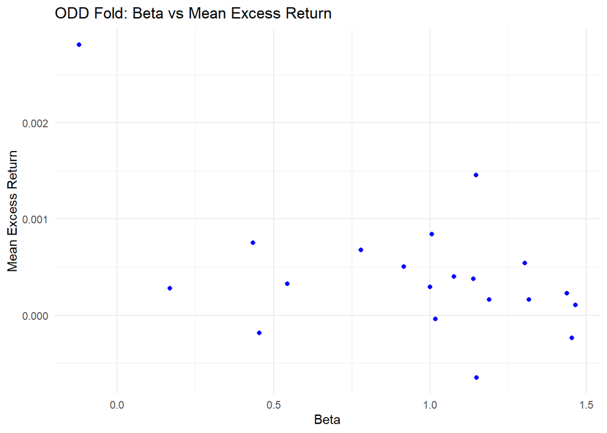

```r
# Beta vs Mean (ODD)
ggplot(capm_odd, aes(x = Beta, y = Mean, label = Asset)) +
  geom_point(color = "blue") +
  ggtitle("ODD Fold: Beta vs Mean Excess Return") +
  xlab("Beta") + ylab("Mean Excess Return") +
  theme_minimal()
```

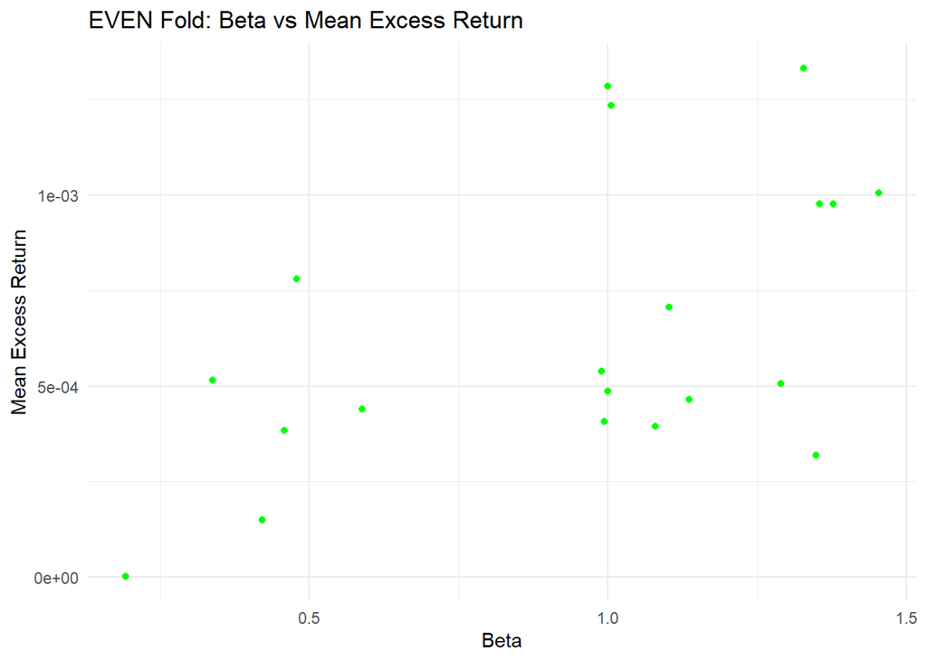

```r
# Beta vs Mean (EVEN)
ggplot(capm_even, aes(x = Beta, y = Mean, label = Asset)) +
  geom_point(color = "green") +
  ggtitle("EVEN Fold: Beta vs Mean Excess Return") +
  xlab("Beta") + ylab("Mean Excess Return") +
  theme_minimal()
```

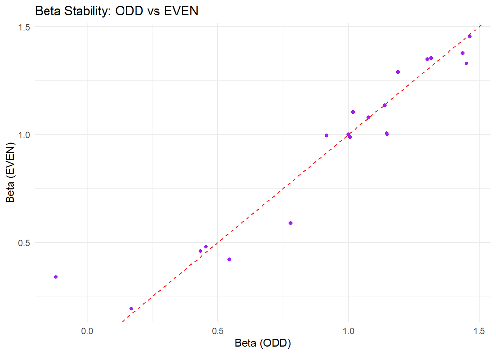

```r
# Beta ODD vs EVEN
ggplot(capm_all, aes(x = Beta_odd, y = Beta_even, label = Asset)) +
  geom_point(color = "purple") +
  geom_abline(slope = 1, intercept = 0, color = "red", linetype = "dashed") +
  ggtitle("Beta Stability: ODD vs EVEN") +
  xlab("Beta (ODD)") + ylab("Beta (EVEN)") +
  theme_minimal()
```

#### How similar are the beta estimates To assess whether the beta values estimated from the odd and even samples differ significantly, I performed a paired t-test. This test compares the CAPM betas from each asset in the odd sample against the corresponding beta in the even sample. Since each asset appears in both samples, a paired test is appropriate to detect systematic differences in beta estimates.

```r
t.test(capm_all$Beta_odd, capm_all$Beta_even, paired = TRUE)
```

```
##
##  Paired t-test
##
## data:  capm_all$Beta_odd and capm_all$Beta_even
## t = -0.10992, df = 19, p-value = 0.9136
## alternative hypothesis: true mean difference is not equal to 0
## 95 percent confidence interval:
##  -0.06709369  0.06039826
## sample estimates:
## mean difference
##    -0.003347718
```

## Question 15

In Question 15, I repeated the portfolio optimization and evaluation steps from Questions 11 and 12, but using the expected returns given by the CAPM model.

```r
estimate_betas <- function(R, market_name = "SPY.Adjusted") {
  market <- R[, market_name]
  sapply(R, function(asset) cov(asset, market, use = "complete.obs") / var(market, na.rm = TRUE))
}

betas <- estimate_betas(excess_returns)
lambda <- mean(excess_returns[, "SPY.Adjusted"], na.rm = TRUE)  # market excess return (mean of SPY)
mu_capm <- betas * lambda
```

```r
# Optimization function using CAPM
optimize_capm_portfolio <- function(R, mu_override, short_selling = TRUE, gamma = 3) {
  R <- R[complete.cases(R), ]
  S <- cov(R, use = "pairwise.complete.obs")
  S <- S + diag(1e-6, ncol(S))

  N <- ncol(R)
  Dmat <- 2 * gamma * S
  dvec <- mu_override[colnames(R)]
  Imat <- diag(N)
  nulvec <- rep(0, N)

  if (short_selling) {
    Amat <- Imat
    bvec <- rep(-1e10, N)
    meq <- 0
  } else {
    Amat <- Imat
    bvec <- nulvec
    meq <- 0
  }

  sol <- solve.QP(Dmat, dvec, Amat, bvec, meq)
  weights <- sol$solution
  names(weights) <- colnames(R)
  return(weights)
}

w_odd_free_capm     <- optimize_capm_portfolio(excess_odd,  mu_capm, short_selling = TRUE)
w_odd_noshort_capm  <- optimize_capm_portfolio(excess_odd,  mu_capm, short_selling = FALSE)
w_even_free_capm    <- optimize_capm_portfolio(excess_even, mu_capm, short_selling = TRUE)
w_even_noshort_capm <- optimize_capm_portfolio(excess_even, mu_capm, short_selling = FALSE)
```

```r
# Evaluate CAPM portfolios on in/out-of-sample
perf_odd_free_capm     <- evaluate_portfolio(w_odd_free_capm, excess_odd)
perf_odd_noshort_capm  <- evaluate_portfolio(w_odd_noshort_capm, excess_odd)
perf_even_free_capm    <- evaluate_portfolio(w_even_free_capm, excess_even)
perf_even_noshort_capm <- evaluate_portfolio(w_even_noshort_capm, excess_even)

val_odd_free_capm     <- evaluate_portfolio(w_odd_free_capm, excess_even)
val_odd_noshort_capm  <- evaluate_portfolio(w_odd_noshort_capm, excess_even)
val_even_free_capm    <- evaluate_portfolio(w_even_free_capm, excess_odd)
val_even_noshort_capm <- evaluate_portfolio(w_even_noshort_capm, excess_odd)

annualize <- function(perf) {
  list(
    mean   = perf$mean * 252,
    sd     = perf$sd * sqrt(252),
    sharpe = perf$sharpe
  )
}

perf_odd_free_capm_annual     <- annualize(perf_odd_free_capm)
perf_odd_noshort_capm_annual  <- annualize(perf_odd_noshort_capm)
perf_even_free_capm_annual    <- annualize(perf_even_free_capm)
perf_even_noshort_capm_annual <- annualize(perf_even_noshort_capm)

val_odd_free_capm_annual     <- annualize(val_odd_free_capm)
val_odd_noshort_capm_annual  <- annualize(val_odd_noshort_capm)
val_even_free_capm_annual    <- annualize(val_even_free_capm)
val_even_noshort_capm_annual <- annualize(val_even_noshort_capm)
```

```r
results_q15 <- data.frame(
  Portfolio = rep(c("ODD - short", "ODD - no short", "EVEN - short", "EVEN - no short"), each = 2),
  Evaluation = rep(c("In-sample", "Out-of-sample"), times = 4),
  AnnualReturn = c(
    perf_odd_free_capm_annual$mean, val_odd_free_capm_annual$mean,
    perf_odd_noshort_capm_annual$mean, val_odd_noshort_capm_annual$mean,
    perf_even_free_capm_annual$mean, val_even_free_capm_annual$mean,
    perf_even_noshort_capm_annual$mean, val_even_noshort_capm_annual$mean
  ),
  AnnualSD = c(
    perf_odd_free_capm_annual$sd, val_odd_free_capm_annual$sd,
    perf_odd_noshort_capm_annual$sd, val_odd_noshort_capm_annual$sd,
    perf_even_free_capm_annual$sd, val_even_free_capm_annual$sd,
    perf_even_noshort_capm_annual$sd, val_even_noshort_capm_annual$sd
  ),
  SharpeRatio = c(
    perf_odd_free_capm_annual$sharpe, val_odd_free_capm_annual$sharpe,
    perf_odd_noshort_capm_annual$sharpe, val_odd_noshort_capm_annual$sharpe,
    perf_even_free_capm_annual$sharpe, val_even_free_capm_annual$sharpe,
    perf_even_noshort_capm_annual$sharpe, val_even_noshort_capm_annual$sharpe
  )
)

results_q15[, 3:5] <- round(results_q15[, 3:5], 3)

results_q15_odd_short    <- subset(results_q15, Portfolio == "ODD - short")
results_q15_odd_noshort  <- subset(results_q15, Portfolio == "ODD - no short")
results_q15_even_short   <- subset(results_q15, Portfolio == "EVEN - short")
results_q15_even_noshort <- subset(results_q15, Portfolio == "EVEN - no short")

styled_table <- function(df, caption) {
  kable(df, format = "html", caption = caption) %>%
    kable_styling(bootstrap_options = c("striped", "hover", "condensed"), full_width = FALSE)
}

styled_table(results_q15_odd_short,    "ODD Fold – Short-Selling Allowed (CAPM)")
```

ODD Fold – Short-Selling Allowed (CAPM)

| Portfolio | Evaluation | AnnualReturn | AnnualSD | SharpeRatio |
| --- | --- | --- | --- | --- |
| ODD - short | In-sample | 0.026 | 0.083 | 0.02 |
| ODD - short | Out-of-sample | 0.050 | 0.079 | 0.04 |

```r
styled_table(results_q15_odd_noshort,  "ODD Fold – No Short-Selling (CAPM)")
```

ODD Fold – No Short-Selling (CAPM)

|  | Portfolio | Evaluation | AnnualReturn | AnnualSD | SharpeRatio |
| --- | --- | --- | --- | --- | --- |
| 3 | ODD - no short | In-sample | 0.031 | 0.083 | 0.024 |
| 4 | ODD - no short | Out-of-sample | 0.054 | 0.077 | 0.044 |

```r
styled_table(results_q15_even_short,   "EVEN Fold – Short-Selling Allowed (CAPM)")
```

EVEN Fold – Short-Selling Allowed (CAPM)

|  | Portfolio | Evaluation | AnnualReturn | AnnualSD | SharpeRatio |
| --- | --- | --- | --- | --- | --- |
| 5 | EVEN - short | In-sample | 0.065 | 0.091 | 0.045 |
| 6 | EVEN - short | Out-of-sample | 0.045 | 0.103 | 0.028 |

```r
styled_table(results_q15_even_noshort, "EVEN Fold – No Short-Selling (CAPM)")
```

EVEN Fold – No Short-Selling (CAPM)

|  | Portfolio | Evaluation | AnnualReturn | AnnualSD | SharpeRatio |
| --- | --- | --- | --- | --- | --- |
| 7 | EVEN - no short | In-sample | 0.066 | 0.090 | 0.046 |
| 8 | EVEN - no short | Out-of-sample | 0.045 | 0.101 | 0.028 |

To better interpret these, I also vizualized them. ### Bar Plots

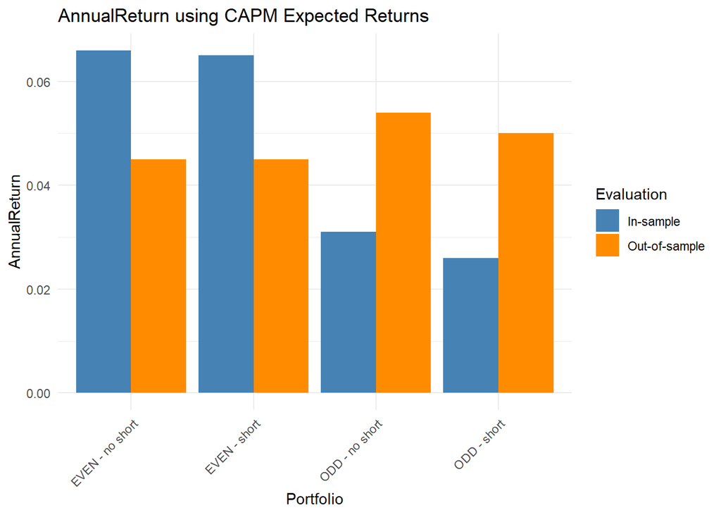

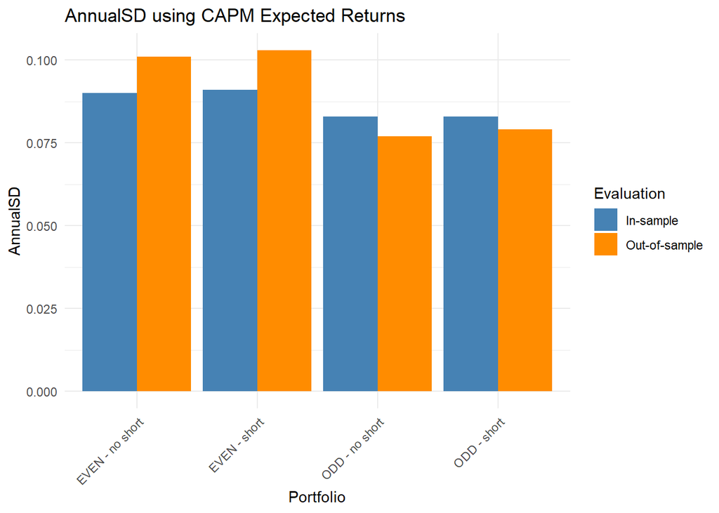

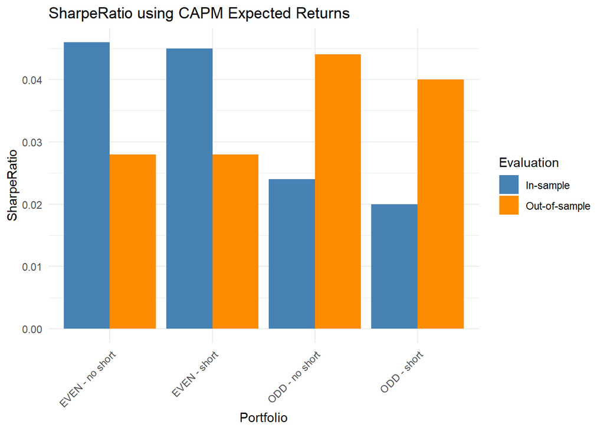

```r
for (metric in c("AnnualReturn", "AnnualSD", "SharpeRatio")) {
  p <- ggplot(results_q15, aes_string(x = "Portfolio", y = metric, fill = "Evaluation")) +
    geom_bar(stat = "identity", position = "dodge") +
    labs(title = paste(metric, "using CAPM Expected Returns"),
         y = metric, x = "Portfolio") +
    theme_minimal() +
    scale_fill_manual(values = c("In-sample" = "steelblue", "Out-of-sample" = "darkorange")) +
    theme(axis.text.x = element_text(angle = 45, hjust = 1))

  print(p)
}
```

The **first graph** shows that the EVEN portfolios achieved higher in-sample returns than the ODD portfolios. Interestingly, the out-of-sample returns are higher than in-sample ones for the ODD portfolios, which is unusual and might suggest overfitting in the even fold or randomness. Overall, the EVEN - short and EVEN - no short portfolios produced the best in-sample performance, though their out-of-sample returns dropped noticeably.

### Comparing with Q12

We then thought it was important to compare them with what we had gotten with the sample means, to do this we thought it easier if it was through side-by-side histograms.

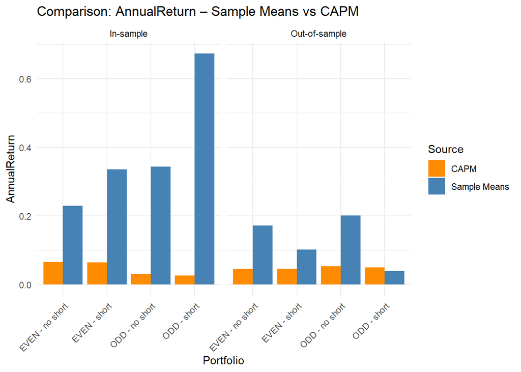

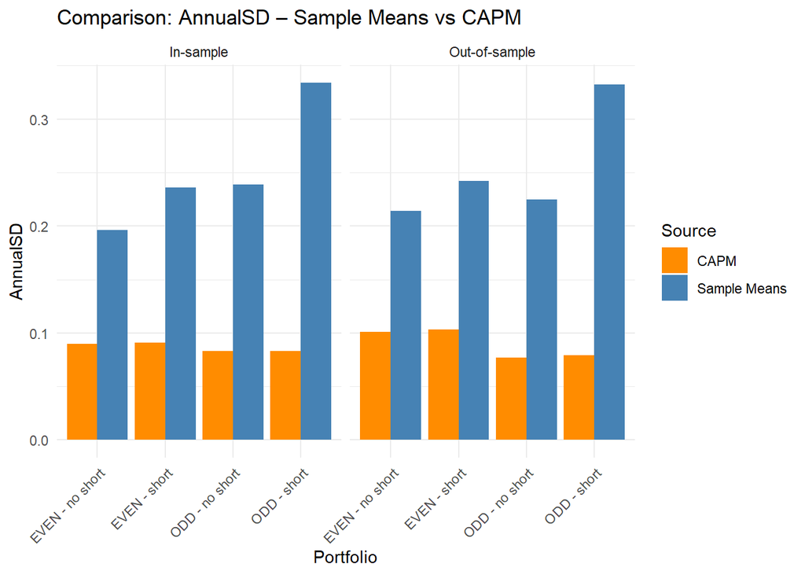

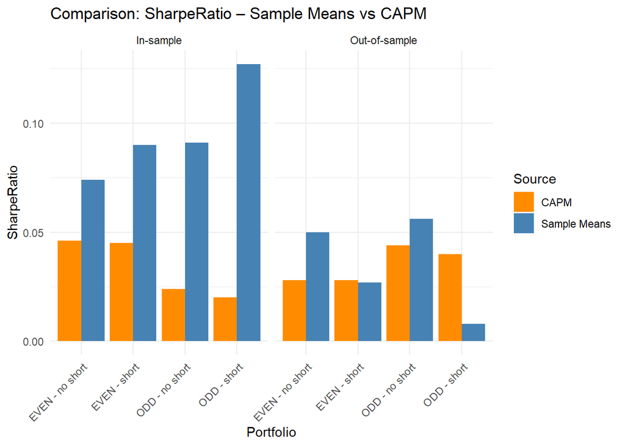

```r
results_q12 <- results_annual_rounded
results_q12$Source <- "Sample Means"
results_q15 <- results_q15
results_q15$Source <- "CAPM"

results_combined <- rbind(results_q12, results_q15)

for (metric in c("AnnualReturn", "AnnualSD", "SharpeRatio")) {
  p <- ggplot(results_combined, aes_string(x = "Portfolio", y = metric, fill = "Source")) +
    geom_bar(stat = "identity", position = "dodge") +
    facet_wrap(~Evaluation) +
    labs(title = paste("Comparison:", metric, "– Sample Means vs CAPM"),
         x = "Portfolio", y = metric) +
    theme_minimal() +
    scale_fill_manual(values = c("Sample Means" = "steelblue", "CAPM" = "darkorange")) +
    theme(axis.text.x = element_text(angle = 45, hjust = 1))

  print(p)
}
```

**Annual Return – Sample Means vs CAPM** The graph shows that portfolios based on sample means show much higher in-sample annual returns compared to those based on CAPM-implied returns. However, these sample-mean portfolios also experience a sharp drop in out-of-sample performance, suggesting overfitting. CAPM-based returns remain much more stable in both samples, indicating better generalizability but at the cost of lower returns.

**Annual Standard Deviation – Sample Means vs CAPM** Sample-mean portfolios exhibit higher annual standard deviation (volatility) than CAPM-based portfolios across both in-sample and out-of-sample periods. CAPM portfolios maintain a lower and more consistent risk profile, which highlights CAPM’s conservative nature and focus on systematic risk.

**Sharpe Ratio – Sample Means vs CAPM** Although sample-mean portfolios achieve higher Sharpe Ratios in-sample, their performance worsens out-of-sample. In contrast, CAPM portfolios show lower but more stable Sharpe Ratios across both samples. This means that while sample means can improve performance in-sample, CAPM may offer more reliable risk-adjusted returns in real-world scenarios.

### Usefulness of CAPM

These conclusions suggest that while CAPM-based portfolios may not deliver the highest returns in-sample, they offer more stable and consistent performance. This stability indicates that CAPM is very useful for portfolio construction, especially when the goal is to avoid overfitting and ensure that the portfolio performs well in unseen data. In real-world investing, where future returns are unknown, the generalizability and reliability of CAPM can outweigh the short-term gains offered by more volatile, sample-mean-based strategies.

## Question 16

**What happened to the weight of the ‘market portfolio’ SPY?**

```r
spy_name <- "SPY.Adjusted"

spy_weights <- c(
  Q11_Odd_Short      = w_odd_free[spy_name],
  Q11_Odd_NoShort    = w_odd_noshort[spy_name],
  Q11_Even_Short     = w_even_free[spy_name],
  Q11_Even_NoShort   = w_even_noshort[spy_name],
  Q15_Odd_Short_CAPM = w_odd_free_capm[spy_name],
  Q15_Odd_NoShort_CAPM = w_odd_noshort_capm[spy_name],
  Q15_Even_Short_CAPM = w_even_free_capm[spy_name],
  Q15_Even_NoShort_CAPM = w_even_noshort_capm[spy_name]
)

spy_weights <- round(spy_weights, 4)
print(spy_weights)
```

```
##         Q11_Odd_Short.SPY.Adjusted       Q11_Odd_NoShort.SPY.Adjusted
##                            -0.9204                             0.0000
##        Q11_Even_Short.SPY.Adjusted      Q11_Even_NoShort.SPY.Adjusted
##                             0.0101                             0.0000
##    Q15_Odd_Short_CAPM.SPY.Adjusted  Q15_Odd_NoShort_CAPM.SPY.Adjusted
##                             0.4014                             0.3637
##   Q15_Even_Short_CAPM.SPY.Adjusted Q15_Even_NoShort_CAPM.SPY.Adjusted
##                             0.4795                             0.4376
```

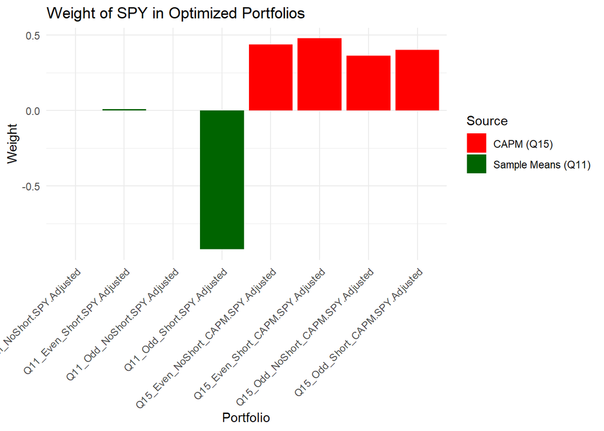

```r
spy_df <- data.frame(
  Portfolio = names(spy_weights),
  SPY_Weight = as.numeric(spy_weights),
  Source = ifelse(grepl("Q11", names(spy_weights)), "Sample Means (Q11)", "CAPM (Q15)")
)

ggplot(spy_df, aes(x = Portfolio, y = SPY_Weight, fill = Source)) +
  geom_bar(stat = "identity") +
  labs(title = "Weight of SPY in Optimized Portfolios",
       y = "Weight", x = "Portfolio") +
  theme_minimal() +
  theme(axis.text.x = element_text(angle = 45, hjust = 1)) +
  scale_fill_manual(values = c("Sample Means (Q11)" = "darkgreen", "CAPM (Q15)" = "red"))
```

# 2.5 - Modeling ## Question 17 To begin, we defined the two extremes of expected returns: the CAPM-implied returns and the historical sample means. Since they are based on different assumptions and both are imperfect, we will later combine them using shrinkage. We also extract the common assets across both sources and calculate their covariance matrices for the odd and even folds, which we will use in the optimization.

```r
# Shrinkage
sample_means <- colMeans(excess_odd, na.rm = TRUE)
capm_means   <- mu_capm  # already defined
common_assets <- intersect(names(sample_means), names(capm_means))

sample_means <- sample_means[common_assets]
capm_means   <- capm_means[common_assets]
cov_odd      <- cov(excess_odd[, common_assets], use = "pairwise.complete.obs")
cov_even     <- cov(excess_even[, common_assets], use = "pairwise.complete.obs")

# Optimization function
optimize_portfolio_with_mu <- function(mu_vec, cov_mat, short_selling = TRUE, gamma = 3) {
  N <- length(mu_vec)
  Dmat <- gamma * cov_mat + diag(1e-6, N)
  dvec <- mu_vec
  Imat <- diag(N)
  nulvec <- rep(0, N)

  if (short_selling) {
    Amat <- Imat
    bvec <- nulvec
    meq  <- 0
  } else {
    Amat <- cbind(rep(1, N), Imat)
    bvec <- c(1, nulvec)
    meq  <- 1
  }

  sol <- solve.QP(Dmat, dvec, Amat, bvec, meq)
  weights <- sol$solution
  names(weights) <- names(mu_vec)
  return(weights)
}
```

```r
evaluate_portfolio_simple <- function(w, R) {
  p_returns <- R %*% w
  return(c(mean = mean(p_returns), sd = sd(p_returns), sharpe = mean(p_returns) / sd(p_returns)))
}
annualize_perf <- function(x) {
  c(AnnualReturn = 252 * x["mean"], AnnualSD = sqrt(252) * x["sd"], SharpeRatio = x["sharpe"])
}
kappa_vals <- seq(0, 1, by = 0.25)
results_kappa <- data.frame()

for (kappa in kappa_vals) {
  mu_shrink <- (1 - kappa) * capm_means + kappa * sample_means

  w_odd_kappa <- optimize_portfolio_with_mu(mu_shrink, cov_odd, short_selling = FALSE)

  in_sample  <- evaluate_portfolio_simple(w_odd_kappa, excess_odd[, common_assets])
  out_sample <- evaluate_portfolio_simple(w_odd_kappa, excess_even[, common_assets])

  results_kappa <- rbind(results_kappa,
    data.frame(Kappa = kappa, Evaluation = "In-sample",  t(annualize_perf(in_sample))),
    data.frame(Kappa = kappa, Evaluation = "Out-of-sample", t(annualize_perf(out_sample)))
  )
}
```

To evaluate how well each portfolio performs, we defined a function to calculate the mean return, risk, and the Sharpe ratio, then annualize them. We looped it over a few κ values and generatec a blended return estimates. For each κ, we compute an optimal portfolio based on the odd sample and test its performance both in-sample and out-of-sample on the even sample. These results are stored in a cumulative data frame.

```r
colnames(results_kappa)[grepl("AnnualReturn", colnames(results_kappa))] <- "AnnualReturn"
colnames(results_kappa)[grepl("AnnualSD", colnames(results_kappa))]     <- "AnnualSD"
colnames(results_kappa)[grepl("SharpeRatio", colnames(results_kappa))]  <- "SharpeRatio"

results_kappa[, c("AnnualReturn", "AnnualSD", "SharpeRatio")] <-
  round(results_kappa[, c("AnnualReturn", "AnnualSD", "SharpeRatio")], 3)

results_kappa[, c("AnnualReturn", "AnnualSD", "SharpeRatio")] <- round(results_kappa[, c("AnnualReturn", "AnnualSD", "SharpeRatio")], 3)
```

After building the results table, we standardize and round the performance metrics for clarity. We then create a table to display the results in a readable format. To help visualize how performance changes with different values of κ, we plot three bar charts showing the Annual Return, Annual Standard Deviation, and Sharpe Ratio, each split by in-sample and out-of-sample evaluation. These visualizations will help us decide if shrinkage actually improves performance, especially in the validation data. This table presents how the performance of your portfolio changes as you vary the factor κ from 0 to 1: **κ = 0 - Pure CAPM** returns; **κ = 1 - Pure sample mean** returns.

```r
kable(results_kappa, format = "html", caption = "Portfolio Performance Across Kappa Values") %>%
  kable_styling(bootstrap_options = c("striped", "hover", "condensed"), full_width = FALSE)
```

Portfolio Performance Across Kappa Values

| Kappa | Evaluation | AnnualReturn | AnnualSD | SharpeRatio |
| --- | --- | --- | --- | --- |
| 0.00 | In-sample | 0.081 | 0.184 | 0.028 |
| 0.00 | Out-of-sample | 0.122 | 0.171 | 0.045 |
| 0.25 | In-sample | 0.264 | 0.196 | 0.085 |
| 0.25 | Out-of-sample | 0.166 | 0.181 | 0.058 |
| 0.50 | In-sample | 0.325 | 0.230 | 0.089 |
| 0.50 | Out-of-sample | 0.203 | 0.215 | 0.060 |
| 0.75 | In-sample | 0.364 | 0.263 | 0.087 |
| 0.75 | Out-of-sample | 0.224 | 0.248 | 0.057 |
| 1.00 | In-sample | 0.398 | 0.299 | 0.084 |
| 1.00 | Out-of-sample | 0.242 | 0.284 | 0.054 |

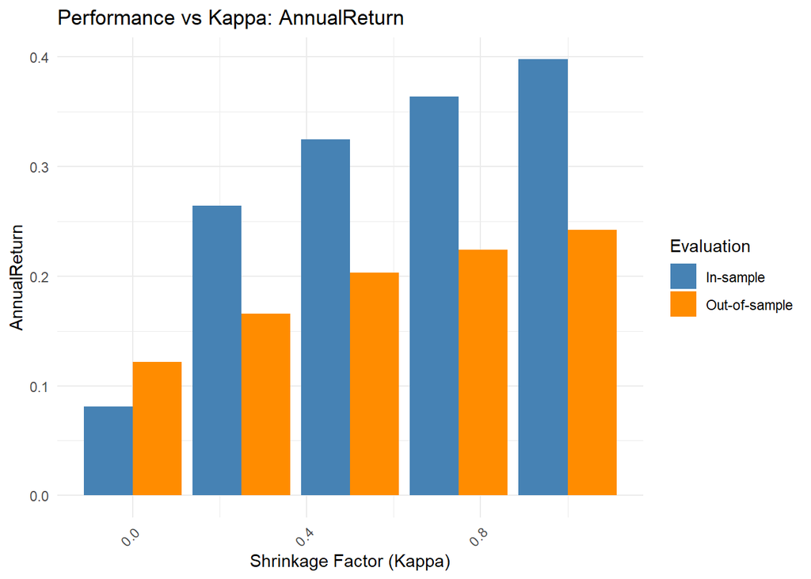

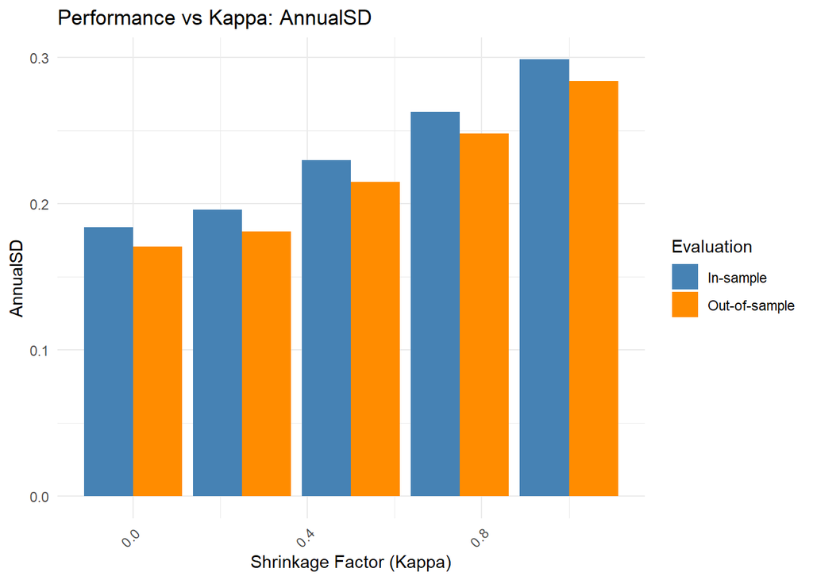

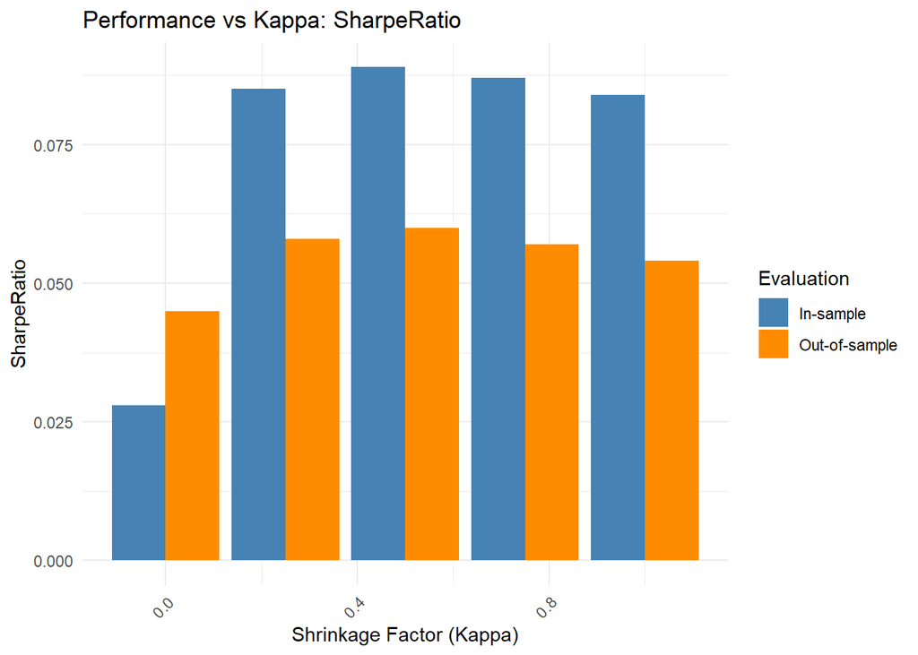

```r
for (metric in c("AnnualReturn", "AnnualSD", "SharpeRatio")) {
  p <- ggplot(results_kappa, aes_string(x = "Kappa", y = metric, fill = "Evaluation")) +
    geom_bar(stat = "identity", position = "dodge") +
    labs(title = paste("Performance vs Kappa:", metric),
         x = "Shrinkage Factor (Kappa)", y = metric) +
    theme_minimal() +
    scale_fill_manual(values = c("In-sample" = "steelblue", "Out-of-sample" = "darkorange")) +
    theme(axis.text.x = element_text(angle = 45, hjust = 1))
  print(p)
}
```

### Do you see improved performance in the validation samples?

Yes, there is improvement in the validation performance when shrinkage is applied (κ > 0). As the shrinkage factor increases from 0 to 0.5, we see improvement in the out-of-sample Sharpe ratio, suggesting that using CAPM-implied returns with empirical sample means can lead to more efficient portfolios. Specifically, while κ = 0 (pure CAPM) has a Sharpe ratio of 0.045, increasing κ to 0.25 and 0.50 raises the Sharpe ratio to 0.058 and 0.060, showing the benefits. However, as κ reaches 1 (putting full weight on the sample means), out-of-sample performance begins to slowly get worse. The Sharpe ratio drops to 0.057 at κ = 0.75 and then to 0.054 at κ = 1. This suggests that while historical means can be informative, relying on them too heavily introduces noise and reduces the model’s generalization ability.

## Question 18

Based on the table, **the best value of κ is 0.5**. At this level of shrinkage, the out-of-sample Sharpe ratio reaches its highest value of 0.060, outperforming both lower (κ = 0 to 0.25) and higher (κ = 0.75 to 1.0) values. This suggests that combining the CAPM-implied returns with historical sample means in equal proportion provides the most reliable and efficient portfolio performance in validation.